# DDS_Project2-JR

### KNN attempt number 2 after narrowing down the sample set based on select variables of which one of them equals 1

```r
library(class)
library(caret)
library(e1071)

Case2_adj = Case2 %>% filter(JobInvolvement == 1 | JobLevel == 1 | JobSatisfaction == 1 | WorkLifeBalance == 1)


set.seed(8)
splitPerc = .7
trainIndices = sample(1:dim(Case2_adj)[1],round(splitPerc * dim(Case2_adj)[1]))
train = Case2_adj[trainIndices,]
test = Case2_adj[-trainIndices,]

# test iterations =  MonthlyIncome, JobRole
classifications = knn(train[,c(20,38)],test[,c(20,38)],train$Attrition, prob = TRUE, k = 15)
t = table(classifications,test$Attrition)
t
```

```
##
## classifications  No Yes
##             No  107  35
##             Yes   4   1
```

```r
confusionMatrix(table(classifications,as.factor(test$Attrition)))
```

```
## Confusion Matrix and Statistics
##
##
## classifications  No Yes
##             No  107  35
##             Yes   4   1
##
##                Accuracy : 0.7347
##                  95% CI : (0.6556, 0.804)
##     No Information Rate : 0.7551
##     P-Value [Acc > NIR] : 0.7518
##
##                   Kappa : -0.0116
##
##  Mcnemar's Test P-Value : 1.556e-06
##
##             Sensitivity : 0.96396
##             Specificity : 0.02778
##          Pos Pred Value : 0.75352
##          Neg Pred Value : 0.20000
##              Prevalence : 0.75510
##          Detection Rate : 0.72789
##    Detection Prevalence : 0.96599
##       Balanced Accuracy : 0.49587
##
##        'Positive' Class : No
##
```

```r
CM = confusionMatrix(table(classifications,as.factor(test$Attrition)))
CM$overall[1]
```

```
##  Accuracy
## 0.7346939
```

```r
# test iterations =  MonthlyIncome, TotalWorkingYears
classifications = knn(train[,c(20,30)],test[,c(20,30)],train$Attrition, prob = TRUE, k = 15)
t = table(classifications,test$Attrition)
t
```

```
##
## classifications  No Yes
##             No  107  35
##             Yes   4   1
```

```r
confusionMatrix(table(classifications,as.factor(test$Attrition)))
```

```
## Confusion Matrix and Statistics
##
##
## classifications  No Yes
##             No  107  35
##             Yes   4   1
##
##                Accuracy : 0.7347
##                  95% CI : (0.6556, 0.804)
##     No Information Rate : 0.7551
##     P-Value [Acc > NIR] : 0.7518
##
##                   Kappa : -0.0116
##
##  Mcnemar's Test P-Value : 1.556e-06
##
##             Sensitivity : 0.96396
##             Specificity : 0.02778
##          Pos Pred Value : 0.75352
##          Neg Pred Value : 0.20000
##              Prevalence : 0.75510
##          Detection Rate : 0.72789
##    Detection Prevalence : 0.96599
##       Balanced Accuracy : 0.49587
##
##        'Positive' Class : No
##
```

```r
CM = confusionMatrix(table(classifications,as.factor(test$Attrition)))
CM$overall[1]
```

```
##  Accuracy
## 0.7346939
```

```r
# internal cross validation test iterations =  MonthlyIncome, TotalWorkingYears
classifications = knn.cv(Case2_adj[,c(20,30)],Case2_adj$Attrition, k = 15)
t = table(classifications,Case2_adj$Attrition)
t
```

```
##
## classifications  No Yes
##             No  364 113
##             Yes  12   0
```

```r
confusionMatrix(table(classifications,as.factor(Case2_adj$Attrition)))
```

```
## Confusion Matrix and Statistics
##
##
## classifications  No Yes
##             No  364 113
##             Yes  12   0
##
##                Accuracy : 0.7444
##                  95% CI : (0.7033, 0.7825)
##     No Information Rate : 0.7689
##     P-Value [Acc > NIR] : 0.9089
##
##                   Kappa : -0.0464
##
##  Mcnemar's Test P-Value : <2e-16
##
##             Sensitivity : 0.9681
##             Specificity : 0.0000
##          Pos Pred Value : 0.7631
##          Neg Pred Value : 0.0000
##              Prevalence : 0.7689
##          Detection Rate : 0.7444
##    Detection Prevalence : 0.9755
##       Balanced Accuracy : 0.4840
##
##        'Positive' Class : No
##
```

```r
CM = confusionMatrix(table(classifications,as.factor(Case2_adj$Attrition)))
CM$overall[1]
```

```
##  Accuracy
## 0.7443763
```

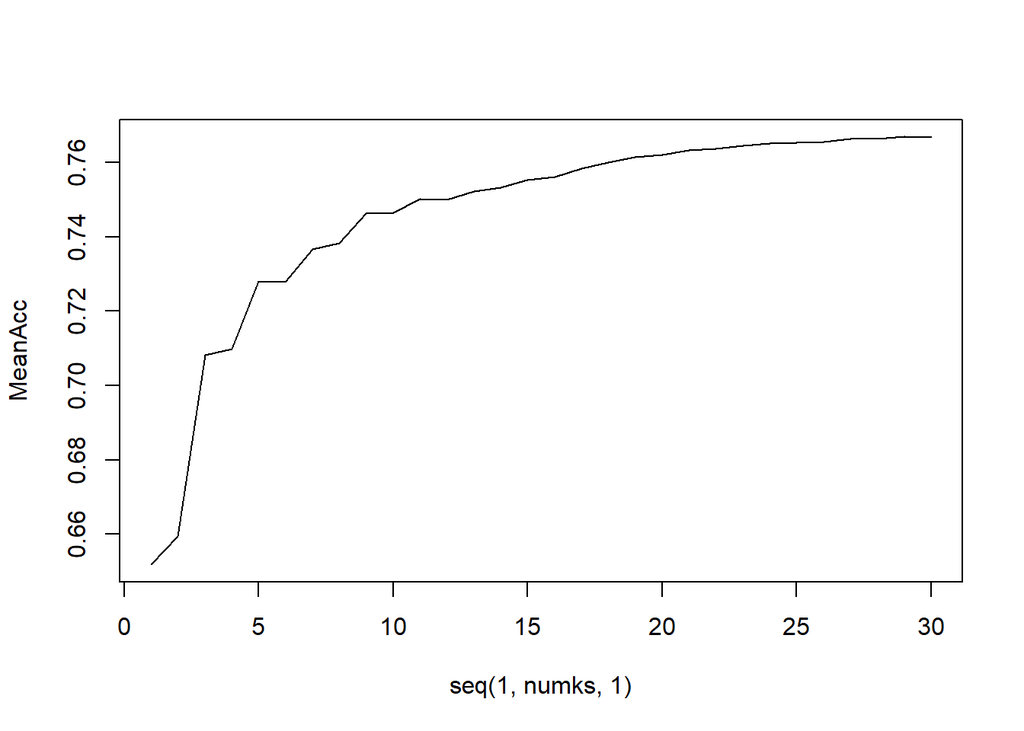

```r
library(class)
library(caret)
library(e1071)

Case2_adj = Case2 %>% filter(JobInvolvement == 1 | JobLevel == 1 | JobSatisfaction == 1 | WorkLifeBalance == 1)

iterations = 500
numks = 30
masterAcc = matrix(nrow = iterations, ncol = numks)

for(j in 1:iterations)
{
accs = data.frame(accuracy = numeric(30), k = numeric(30))
trainIndices = sample(1:dim(Case2_adj)[1],round(splitPerc * dim(Case2_adj)[1]))
train = Case2_adj[trainIndices,]
test = Case2_adj[-trainIndices,]
for(i in 1:numks)
{
  classifications = knn(train[,c(20,30)],test[,c(20,30)],train$Attrition, prob = TRUE, k = i)
  table(classifications,test$Attrition)
  CM = confusionMatrix(table(classifications,test$Attrition))
  masterAcc[j,i] = CM$overall[1]
}
}
MeanAcc = colMeans(masterAcc)
plot(seq(1,numks,1),MeanAcc, type = "l")
```

### Repeat these two models with more iterations to determine best k amount to use

### Based on the graph, k = 15 looks ideal as the accuracy is near the peak yet is mindful of cost of each k for client

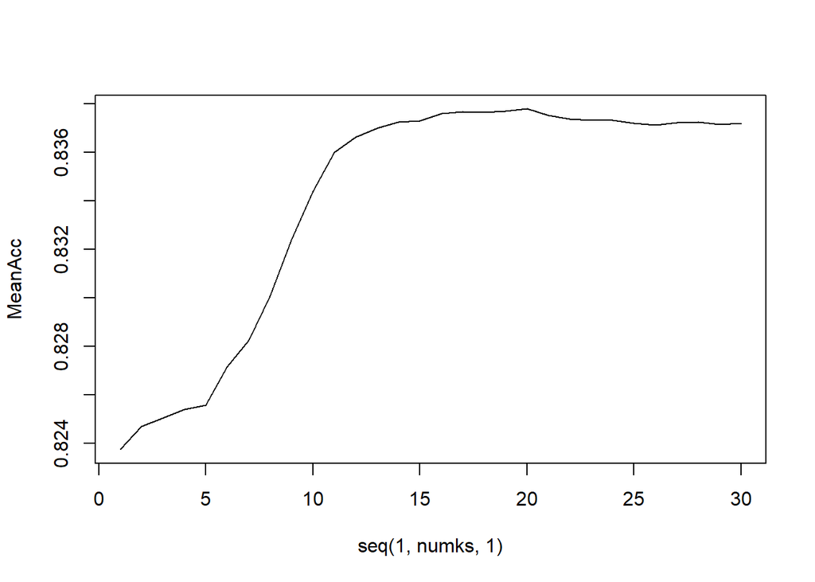

```r
set.seed(8)
splitPerc = .7
trainIndices = sample(1:dim(Case2)[1],round(splitPerc * dim(Case2)[1]))
train = Case2[trainIndices,]
test = Case2[-trainIndices,]

iterations = 500
numks = 30
masterAcc = matrix(nrow = iterations, ncol = numks)

for(j in 1:iterations)
{
accs = data.frame(accuracy = numeric(30), k = numeric(30))
trainIndices = sample(1:dim(Case2)[1],round(splitPerc * dim(Case2)[1]))
train = Case2[trainIndices,]
test = Case2[-trainIndices,]
for(i in 1:numks)
{
  classifications = knn(train[,c(30,58)],test[,c(30,58)],train$Attrition, prob = TRUE, k = i)
  table(classifications,test$Attrition)
  CM = confusionMatrix(table(classifications,test$Attrition))
  masterAcc[j,i] = CM$overall[1]
}
}
MeanAcc = colMeans(masterAcc)
plot(seq(1,numks,1),MeanAcc, type = "l")
```

### Unable to model data with sufficient efficacy using KNN so moved on to NaiveBayes

```r
model = naiveBayes(Case2[,c(17,55)],Case2$Attrition,laplace = 1)
table(predict(model,Case2[,c(17,55)]),Case2$Attrition)
```

```
##
##        No Yes
##   No  699 123
##   Yes  31  17
```

```r
CM = confusionMatrix(table(predict(model,Case2[,c(17,55)]),Case2$Attrition))
CM
```

```
## Confusion Matrix and Statistics
##
##
##        No Yes
##   No  699 123
##   Yes  31  17
##
##                Accuracy : 0.823
##                  95% CI : (0.796, 0.8478)
##     No Information Rate : 0.8391
##     P-Value [Acc > NIR] : 0.9083
##
##                   Kappa : 0.1075
##
##  Mcnemar's Test P-Value : 2.251e-13
##
##             Sensitivity : 0.9575
##             Specificity : 0.1214
##          Pos Pred Value : 0.8504
##          Neg Pred Value : 0.3542
##              Prevalence : 0.8391
##          Detection Rate : 0.8034
##    Detection Prevalence : 0.9448
##       Balanced Accuracy : 0.5395
##
##        'Positive' Class : No
##
```

```r
model = naiveBayes(Case2[,c(17,56)],Case2$Attrition,laplace = 1)
table(predict(model,Case2[,c(17,56)]),Case2$Attrition)
```

```
##
##        No Yes
##   No  680 108
##   Yes  50  32
```

```r
CM = confusionMatrix(table(predict(model,Case2[,c(17,56)]),Case2$Attrition))
CM
```

```
## Confusion Matrix and Statistics
##
##
##        No Yes
##   No  680 108
##   Yes  50  32
##
##                Accuracy : 0.8184
##                  95% CI : (0.7911, 0.8435)
##     No Information Rate : 0.8391
##     P-Value [Acc > NIR] : 0.9543
##
##                   Kappa : 0.1923
##
##  Mcnemar's Test P-Value : 5.769e-06
##
##             Sensitivity : 0.9315
##             Specificity : 0.2286
##          Pos Pred Value : 0.8629
##          Neg Pred Value : 0.3902
##              Prevalence : 0.8391
##          Detection Rate : 0.7816
##    Detection Prevalence : 0.9057
##       Balanced Accuracy : 0.5800
##
##        'Positive' Class : No
##
```

```r
model = naiveBayes(Case2[,c(30,55)],Case2$Attrition,laplace = 1)
table(predict(model,Case2[,c(30,55)]),Case2$Attrition)
```

```
##
##        No Yes
##   No  699 123
##   Yes  31  17
```

```r
CM = confusionMatrix(table(predict(model,Case2[,c(30,55)]),Case2$Attrition))
CM
```

```
## Confusion Matrix and Statistics
##
##
##        No Yes
##   No  699 123
##   Yes  31  17
##
##                Accuracy : 0.823
##                  95% CI : (0.796, 0.8478)
##     No Information Rate : 0.8391
##     P-Value [Acc > NIR] : 0.9083
##
##                   Kappa : 0.1075
##
##  Mcnemar's Test P-Value : 2.251e-13
##
##             Sensitivity : 0.9575
##             Specificity : 0.1214
##          Pos Pred Value : 0.8504
##          Neg Pred Value : 0.3542
##              Prevalence : 0.8391
##          Detection Rate : 0.8034
##    Detection Prevalence : 0.9448
##       Balanced Accuracy : 0.5395
##
##        'Positive' Class : No
##
```

```r
model = naiveBayes(Case2[,c(30,58)],Case2$Attrition,laplace = 1)
table(predict(model,Case2[,c(30,58)]),Case2$Attrition)
```

```
##
##        No Yes
##   No  667  98
##   Yes  63  42
```

```r
CM = confusionMatrix(table(predict(model,Case2[,c(30,58)]),Case2$Attrition))
CM
```

```
## Confusion Matrix and Statistics
##
##
##        No Yes
##   No  667  98
##   Yes  63  42
##
##                Accuracy : 0.8149
##                  95% CI : (0.7875, 0.8402)
##     No Information Rate : 0.8391
##     P-Value [Acc > NIR] : 0.974729
##
##                   Kappa : 0.2377
##
##  Mcnemar's Test P-Value : 0.007372
##
##             Sensitivity : 0.9137
##             Specificity : 0.3000
##          Pos Pred Value : 0.8719
##          Neg Pred Value : 0.4000
##              Prevalence : 0.8391
##          Detection Rate : 0.7667
##    Detection Prevalence : 0.8793
##       Balanced Accuracy : 0.6068
##
##        'Positive' Class : No
##
```

```r
model = naiveBayes(Case2[,c(17,58)],Case2$Attrition,laplace = 1)
table(predict(model,Case2[,c(17,58)]),Case2$Attrition)
```

```
##
##        No Yes
##   No  667  98
##   Yes  63  42
```

```r
CM = confusionMatrix(table(predict(model,Case2[,c(17,58)]),Case2$Attrition))
CM
```

```
## Confusion Matrix and Statistics
##
##
##        No Yes
##   No  667  98
##   Yes  63  42
##
##                Accuracy : 0.8149
##                  95% CI : (0.7875, 0.8402)
##     No Information Rate : 0.8391
##     P-Value [Acc > NIR] : 0.974729
##
##                   Kappa : 0.2377
##
##  Mcnemar's Test P-Value : 0.007372
##
##             Sensitivity : 0.9137
##             Specificity : 0.3000
##          Pos Pred Value : 0.8719
##          Neg Pred Value : 0.4000
##              Prevalence : 0.8391
##          Detection Rate : 0.7667
##    Detection Prevalence : 0.8793
##       Balanced Accuracy : 0.6068
##
##        'Positive' Class : No
##
```

### Repeat NB model with aforementioned adjustments above

```r
Case2_adj = Case2 %>% filter(JobInvolvement == 1 | JobLevel == 1 | JobSatisfaction == 1 | WorkLifeBalance == 1)

set.seed(8)
splitPerc = .7
trainIndices = sample(1:dim(Case2_adj)[1],round(splitPerc * dim(Case2_adj)[1]))
train = Case2_adj[trainIndices,]
test = Case2_adj[-trainIndices,]

model = naiveBayes(Case2_adj[,c(30,58)],Case2_adj$Attrition,laplace = 1)
table(predict(model,Case2_adj[,c(30,58)]),Case2_adj$Attrition)
```

```
##
##        No Yes
##   No  323  75
##   Yes  53  38
```

```r
CM = confusionMatrix(table(predict(model,Case2_adj[,c(30,58)]),Case2_adj$Attrition))
CM
```

```
## Confusion Matrix and Statistics
##
##
##        No Yes
##   No  323  75
##   Yes  53  38
##
##                Accuracy : 0.7382
##                  95% CI : (0.6969, 0.7767)
##     No Information Rate : 0.7689
##     P-Value [Acc > NIR] : 0.95024
##
##                   Kappa : 0.2096
##
##  Mcnemar's Test P-Value : 0.06343
##
##             Sensitivity : 0.8590
##             Specificity : 0.3363
##          Pos Pred Value : 0.8116
##          Neg Pred Value : 0.4176
##              Prevalence : 0.7689
##          Detection Rate : 0.6605
##    Detection Prevalence : 0.8139
##       Balanced Accuracy : 0.5977
##
##        'Positive' Class : No
##
```

```r
model
```

```
##
## Naive Bayes Classifier for Discrete Predictors
##
## Call:
## naiveBayes.default(x = Case2_adj[, c(30, 58)], y = Case2_adj$Attrition,
##     laplace = 1)
##
## A-priori probabilities:
## Case2_adj$Attrition
##        No       Yes
## 0.7689162 0.2310838
##
## Conditional probabilities:
##                    TotalWorkingYears
## Case2_adj$Attrition     [,1]     [,2]
##                 No  9.101064 6.509513
##                 Yes 7.000000 6.587325
##
##                    JIJSJLWLB_1
## Case2_adj$Attrition      [,1]      [,2]
##                 No  0.1675532 0.3739667
##                 Yes 0.3716814 0.4854065
```

```r
### This was the highest I was able to get Specificity with my models so am going with this one
### Build model then load select columns and write to csv
model1 = naiveBayes(Case2_adj[,c(17,58)],Case2_adj$Attrition,laplace = 1)
summary(model1)
```

```
##           Length Class  Mode
## apriori   2      table  numeric
## tables    2      -none- list
## levels    2      -none- character
## isnumeric 2      -none- logical
## call      4      -none- call
```

```r
NBmodel = table(predict(model1,Case2_adj[,c(17,58)]),Case2_adj$Attrition)
NBmodelPred = predict(model1, newdata = test)
NBmodelPred
```

```
##   [1] Yes No  Yes No  No  No  No  Yes Yes No  Yes Yes No  No  No  No  No  No
##  [19] Yes Yes No  No  No  Yes Yes No  No  No  Yes No  Yes No  No  No  No  No
##  [37] No  Yes No  No  No  No  No  Yes No  No  No  No  No  Yes Yes No  Yes No
##  [55] No  No  Yes Yes Yes No  No  No  No  No  No  No  Yes Yes No  No  No  No
##  [73] No  No  No  No  No  No  No  Yes No  No  No  No  No  Yes No  No  No  Yes
##  [91] No  No  No  No  No  No  No  No  No  No  No  Yes No  Yes No  No  Yes No
## [109] No  No  No  No  No  No  No  No  Yes Yes No  Yes No  Yes No  No  No  No
## [127] No  No  No  No  Yes No  No  No  Yes No  No  Yes No  Yes No  No  No  No
## [145] No  No  No
## Levels: No Yes
```

```r
NBM = as.data.frame(NBmodelPred)
NBM
```

```
##     NBmodelPred
## 1           Yes
## 2            No
## 3           Yes
## 4            No
## 5            No
## 6            No
## 7            No
## 8           Yes
## 9           Yes
## 10           No
## 11          Yes
## 12          Yes
## 13           No
## 14           No
```

[output cut: 133 more lines]

```r
test
```

```
##      ID Age Attrition    BusinessTravel DailyRate             Department
## 1   254  31       Yes     Travel_Rarely       359        Human Resources
## 2   398  34       Yes     Travel_Rarely      1107        Human Resources
## 4   716  24       Yes     Travel_Rarely       240        Human Resources
## 5   733  27       Yes Travel_Frequently      1337        Human Resources
## 9    81  37       Yes     Travel_Rarely      1141 Research & Development
## 15  162  28       Yes        Non-Travel      1366 Research & Development
## 16  177  55       Yes     Travel_Rarely       725 Research & Development
## 17  178  26       Yes Travel_Frequently       342 Research & Development
## 18  204  28       Yes     Travel_Rarely       654 Research & Development
## 23  287  22       Yes     Travel_Rarely       391 Research & Development
## 25  299  31       Yes        Non-Travel       335 Research & Development
## 28  313  31       Yes Travel_Frequently       561 Research & Development
## 29  333  44       Yes Travel_Frequently       429 Research & Development
## 32  380  30       Yes     Travel_Rarely       138 Research & Development
```

[output cut: 1761 more lines]

```r
CM = confusionMatrix(table(predict(model1,Case2_adj[,c(17,58)]),Case2_adj$Attrition))
CM
```

```
## Confusion Matrix and Statistics
##
##
##        No Yes
##   No  314  72
##   Yes  62  41
##
##                Accuracy : 0.726
##                  95% CI : (0.6841, 0.7651)
##     No Information Rate : 0.7689
##     P-Value [Acc > NIR] : 0.9884
##
##                   Kappa : 0.2043
##
##  Mcnemar's Test P-Value : 0.4369
##
##             Sensitivity : 0.8351
##             Specificity : 0.3628
##          Pos Pred Value : 0.8135
##          Neg Pred Value : 0.3981
##              Prevalence : 0.7689
##          Detection Rate : 0.6421
##    Detection Prevalence : 0.7894
##       Balanced Accuracy : 0.5990
##
##        'Positive' Class : No
##
```

```r
IDdf = as.data.frame(test[,c(1)])
IDdf
```

```
##     test[, c(1)]
## 1            254
## 2            398
## 3            716
## 4            733
## 5             81
## 6            162
## 7            177
## 8            178
## 9            204
## 10           287
## 11           299
## 12           313
## 13           333
## 14           380
```

[output cut: 133 more lines]

```r
PredNB = cbind(IDdf, NBM)
PredNB
```

```
##     test[, c(1)] NBmodelPred
## 1            254         Yes
## 2            398          No
## 3            716         Yes
## 4            733          No
## 5             81          No
## 6            162          No
## 7            177          No
## 8            178         Yes
## 9            204         Yes
## 10           287          No
## 11           299         Yes
## 12           313         Yes
## 13           333          No
## 14           380          No
```

[output cut: 133 more lines]

```r
colnames(PredNB) = c("ID", "Attrition")
PredNB
```

```
##      ID Attrition
## 1   254       Yes
## 2   398        No
## 3   716       Yes
## 4   733        No
## 5    81        No
## 6   162        No
## 7   177        No
## 8   178       Yes
## 9   204       Yes
## 10  287        No
## 11  299       Yes
## 12  313       Yes
## 13  333        No
## 14  380        No
```

[output cut: 133 more lines]

```r
write.csv(PredNB,"C:/Users/Team Reed/OneDrive/JEFF/SMU/Doing Data Science/Project 2/Case2PredictionsReedAttrition.csv")
```

### Salary / MonthlyIncome Linear Regression Model

### Check all correlations then focus on correlation between the most notable MonthlyIncome and JobLevel, TotalWorkingYears, YearsAtCompany and Age

### Key variables based on correlation = JobLevel,TotalWorkingYears

```r
  df5 = Case2[,c(20,16,30,33,2)]
  summary(df5)
```

```
##  MonthlyIncome      JobLevel     TotalWorkingYears YearsAtCompany
##  Min.   : 1081   Min.   :1.000   Min.   : 0.00     Min.   : 0.000
##  1st Qu.: 2840   1st Qu.:1.000   1st Qu.: 6.00     1st Qu.: 3.000
##  Median : 4946   Median :2.000   Median :10.00     Median : 5.000
##  Mean   : 6390   Mean   :2.039   Mean   :11.05     Mean   : 6.962
##  3rd Qu.: 8182   3rd Qu.:3.000   3rd Qu.:15.00     3rd Qu.:10.000
##  Max.   :19999   Max.   :5.000   Max.   :40.00     Max.   :40.000
##       Age
##  Min.   :18.00
##  1st Qu.:30.00
##  Median :35.00
##  Mean   :36.83
##  3rd Qu.:43.00
##  Max.   :60.00
```

```r
  corr = cor(df5)
  round(corr, 2)
```

```
##                   MonthlyIncome JobLevel TotalWorkingYears YearsAtCompany  Age
## MonthlyIncome              1.00     0.95              0.78           0.49 0.48
## JobLevel                   0.95     1.00              0.78           0.52 0.48
## TotalWorkingYears          0.78     0.78              1.00           0.64 0.65
## YearsAtCompany             0.49     0.52              0.64           1.00 0.29
## Age                        0.48     0.48              0.65           0.29 1.00
```

### Create linear regression model to forecast salary / MonthlyIncome

### Start with plotting the models

```r
set.seed(10)
splitPerc = .7
trainIndices = sample(1:dim(Case2)[1],round(splitPerc * dim(Case2)[1]))
train = Case2[trainIndices,]
test = Case2[-trainIndices,]

### Simple Linear Regression between MonthlyIncome and TotalWorking Years
fit1 <- lm(MonthlyIncome ~ TotalWorkingYears, data = train)
summary(fit1)
```

```
##
## Call:
## lm(formula = MonthlyIncome ~ TotalWorkingYears, data = train)
##
## Residuals:
##     Min      1Q  Median      3Q     Max
## -7813.7 -1745.5     6.7  1422.9 10995.6
##
## Coefficients:
##                   Estimate Std. Error t value Pr(>|t|)
## (Intercept)         1134.7      209.0    5.43 8.16e-08 ***
## TotalWorkingYears    476.9       15.8   30.17  < 2e-16 ***
## ---
## Signif. codes:  0 '***' 0.001 '**' 0.01 '*' 0.05 '.' 0.1 ' ' 1
##
## Residual standard error: 2864 on 607 degrees of freedom
## Multiple R-squared:    0.6,  Adjusted R-squared:  0.5993
## F-statistic: 910.5 on 1 and 607 DF,  p-value: < 2.2e-16
```

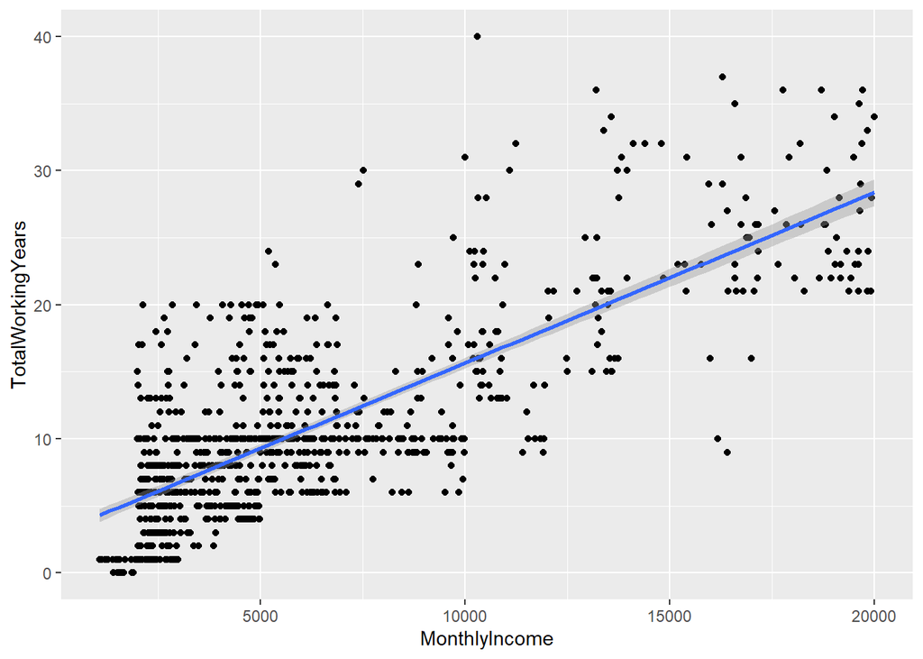

```r
Case2 %>% ggplot(aes(x = MonthlyIncome, y = TotalWorkingYears)) + geom_point() + geom_smooth(method = "lm")
```

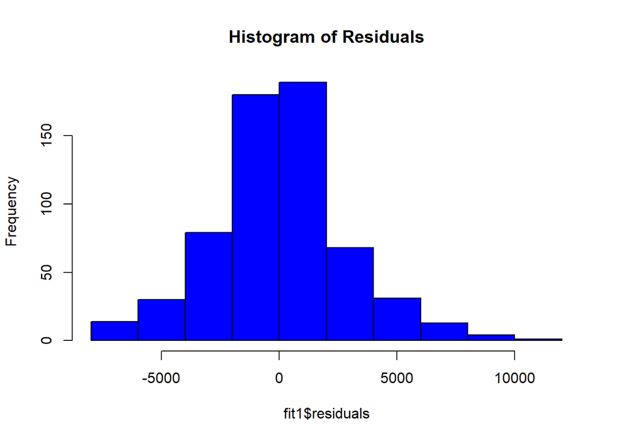

```r
hist(fit1$residuals, col = "blue", main = "Histogram of Residuals")
```

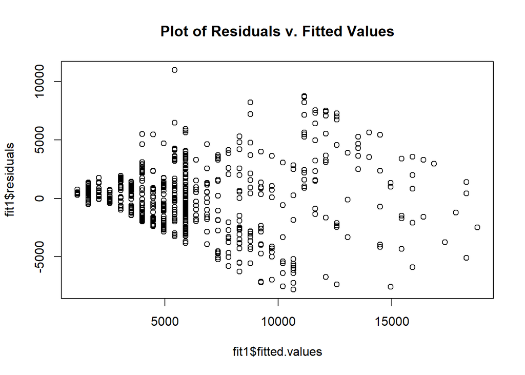

```r
plot(fit1$fitted.values,fit1$residuals, main = "Plot of Residuals v. Fitted Values")
```

```r
Model1_Preds = predict(fit1, newdata = test)
as.data.frame(Model1_Preds)
```

```
##     Model1_Preds
## 14      5903.226
## 16      4949.523
## 21      5903.226
## 23      6380.078
## 24      4949.523
## 28      3042.115
## 29      3518.967
## 30      4472.671
## 34      3995.819
## 37      9718.041
## 38      3042.115
## 44     20208.782
## 47      3995.819
## 49      3518.967
```

[output cut: 247 more lines]

```r
# Model 1
MSPE = data.frame(Observed = test$MonthlyIncome, Predicted = Model1_Preds)
MSPE$Residual = MSPE$Observed - MSPE$Predicted
MSPE$SquaredResidual = MSPE$Residual^2
MSPE
```

```
##     Observed Predicted     Residual SquaredResidual
## 14      3919  5903.226 -1984.226478    3.937155e+06
## 16      2404  4949.523 -2545.522771    6.479686e+06
## 21      2216  5903.226 -3687.226478    1.359564e+07
## 23      2362  6380.078 -4018.078331    1.614495e+07
## 24      2436  4949.523 -2513.522771    6.317797e+06
## 28      2321  3042.115  -721.115359    5.200074e+05
## 29      3464  3518.967   -54.967212    3.021394e+03
## 30      2479  4472.671 -1993.670918    3.974724e+06
## 34      2546  3995.819 -1449.819065    2.101975e+06
## 37      2461  9718.041 -7257.041304    5.266465e+07
## 38      3730  3042.115   687.884641    4.731853e+05
## 44     10312 20208.782 -9896.782075    9.794630e+07
## 47      2028  3995.819 -1967.819065    3.872312e+06
## 49      2587  3518.967  -931.967212    8.685629e+05
```

[output cut: 247 more lines]

```r
mean(MSPE$SquaredResidual)
```

```
## [1] 8652707
```

```r
### Simple Linear Regression between MonthlyIncome and JobLevel
fit2 <- lm(MonthlyIncome ~ JobLevel, data = Case2)
summary(fit2)
```

```
##
## Call:
## lm(formula = MonthlyIncome ~ JobLevel, data = Case2)
##
## Residuals:
##     Min      1Q  Median      3Q     Max
## -5037.1  -928.2    80.1   697.1  3723.6
##
## Coefficients:
##             Estimate Std. Error t value Pr(>|t|)
## (Intercept) -1793.93     101.68  -17.64   <2e-16 ***
## JobLevel     4013.67      43.98   91.26   <2e-16 ***
## ---
## Signif. codes:  0 '***' 0.001 '**' 0.01 '*' 0.05 '.' 0.1 ' ' 1
##
## Residual standard error: 1413 on 868 degrees of freedom
## Multiple R-squared:  0.9056, Adjusted R-squared:  0.9055
## F-statistic:  8329 on 1 and 868 DF,  p-value: < 2.2e-16
```

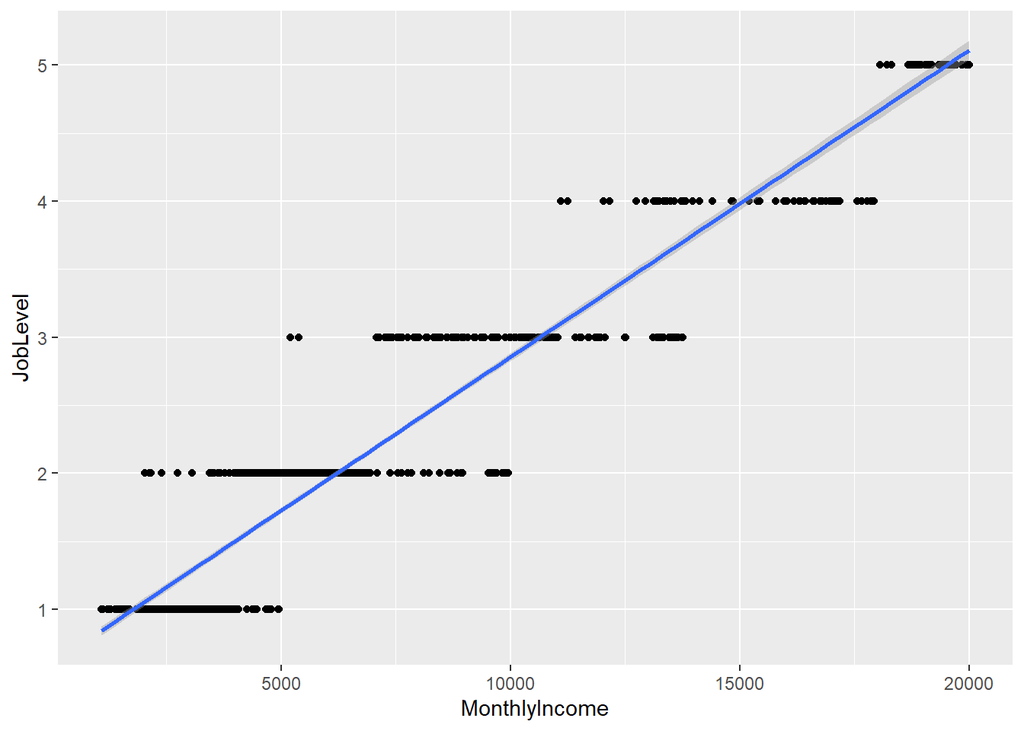

```r
Case2 %>% ggplot(aes(x = MonthlyIncome, y = JobLevel)) + geom_point() + geom_smooth(method = "lm")
```

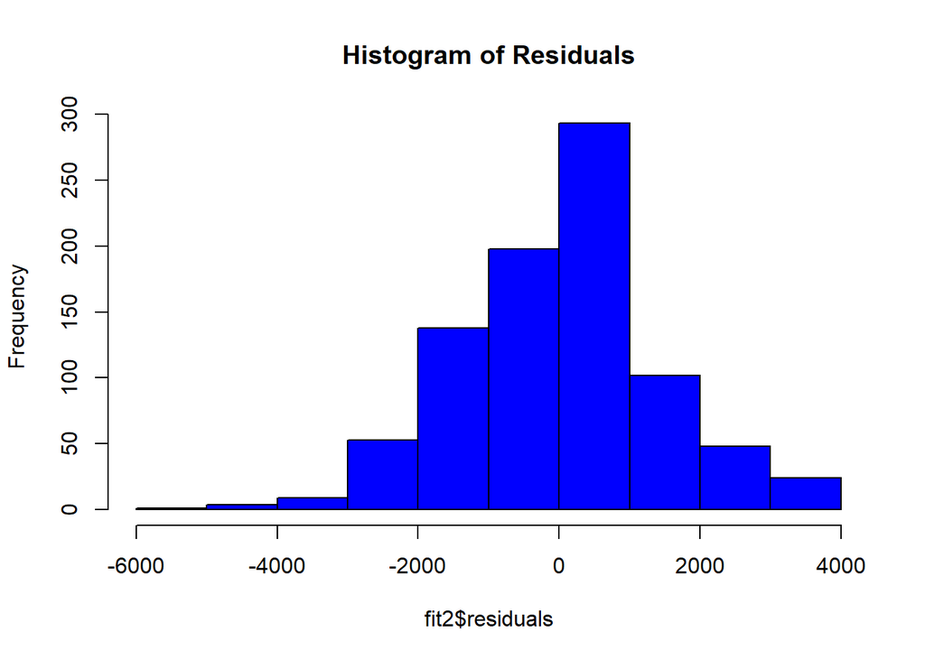

```r
hist(fit2$residuals, col = "blue", main = "Histogram of Residuals")
```

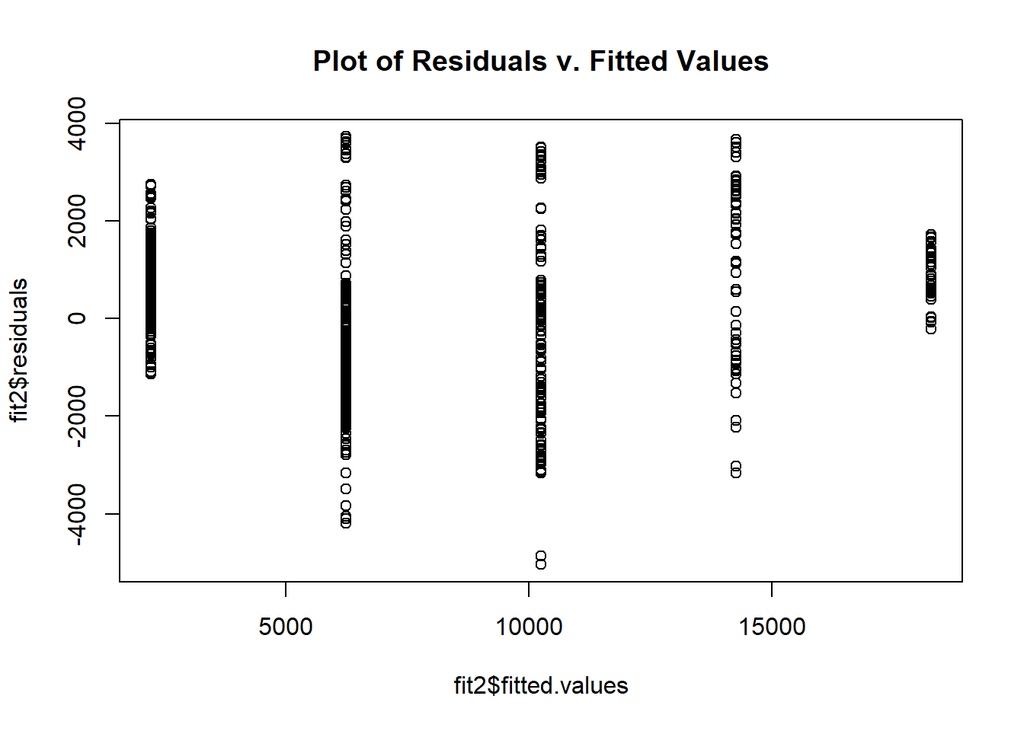

```r
plot(fit2$fitted.values,fit2$residuals, main = "Plot of Residuals v. Fitted Values")
```

```r
Model2_Preds = predict(fit2, newdata = test)
as.data.frame(Model2_Preds)
```

```
##     Model2_Preds
## 14      2219.737
## 16      2219.737
## 21      2219.737
## 23      2219.737
## 24      2219.737
## 28      2219.737
## 29      2219.737
## 30      2219.737
## 34      2219.737
## 37      2219.737
## 38      2219.737
## 44     10247.080
## 47      2219.737
## 49      2219.737
```

[output cut: 247 more lines]

```r
# Model 2
MSPE = data.frame(Observed = test$MonthlyIncome, Predicted = Model2_Preds)
MSPE$Residual = MSPE$Observed - MSPE$Predicted
MSPE$SquaredResidual = MSPE$Residual^2
MSPE
```

```
##     Observed Predicted     Residual SquaredResidual
## 14      3919  2219.737  1699.263047    2.887495e+06
## 16      2404  2219.737   184.263047    3.395287e+04
## 21      2216  2219.737    -3.736953    1.396482e+01
## 23      2362  2219.737   142.263047    2.023877e+04
## 24      2436  2219.737   216.263047    4.676971e+04
## 28      2321  2219.737   101.263047    1.025420e+04
## 29      3464  2219.737  1244.263047    1.548191e+06
## 30      2479  2219.737   259.263047    6.721733e+04
## 34      2546  2219.737   326.263047    1.064476e+05
## 37      2461  2219.737   241.263047    5.820786e+04
## 38      3730  2219.737  1510.263047    2.280894e+06
## 44     10312 10247.080    64.920456    4.214666e+03
## 47      2028  2219.737  -191.736953    3.676306e+04
## 49      2587  2219.737   367.263047    1.348821e+05
```

[output cut: 247 more lines]

```r
mean(MSPE$SquaredResidual)
```

```
## [1] 1887539
```

```r
### Chosen model based on RMSE and visualization of assumptions
### Multiple Linear Regression between MonthlyIncome and JobLevel + TotalWorkingYears
fit3 <- lm(MonthlyIncome ~ JobLevel + TotalWorkingYears, data = Case2)
summary(fit3)
```

```
##
## Call:
## lm(formula = MonthlyIncome ~ JobLevel + TotalWorkingYears, data = Case2)
##
## Residuals:
##     Min      1Q  Median      3Q     Max
## -5469.9  -876.8    64.5   728.3  3937.5
##
## Coefficients:
##                   Estimate Std. Error t value Pr(>|t|)
## (Intercept)       -1798.38      99.98 -17.987  < 2e-16 ***
## JobLevel           3714.12      69.21  53.664  < 2e-16 ***
## TotalWorkingYears    55.66      10.04   5.544 3.94e-08 ***
## ---
## Signif. codes:  0 '***' 0.001 '**' 0.01 '*' 0.05 '.' 0.1 ' ' 1
##
## Residual standard error: 1390 on 867 degrees of freedom
## Multiple R-squared:  0.9088, Adjusted R-squared:  0.9086
## F-statistic:  4322 on 2 and 867 DF,  p-value: < 2.2e-16
```

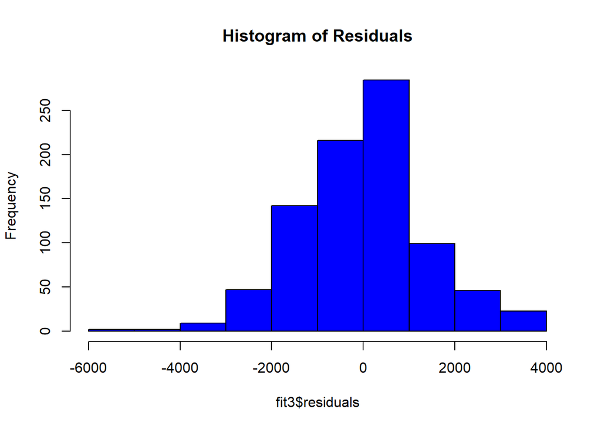

```r
hist(fit3$residuals, col = "blue", main = "Histogram of Residuals")
```

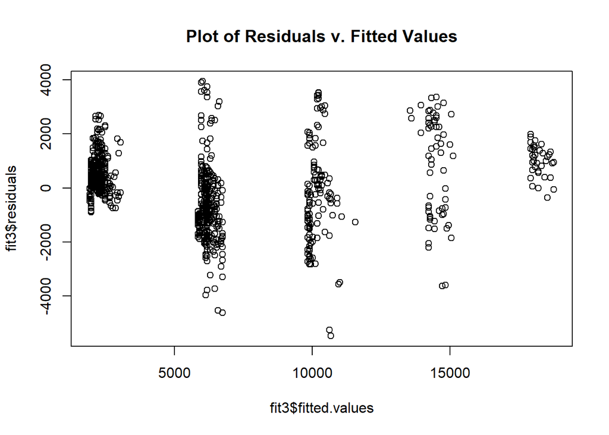

```r
plot(fit3$fitted.values,fit3$residuals, main = "Plot of Residuals v. Fitted Values")
```

```r
Model3_Preds = predict(fit3, newdata = test)
LRM = as.data.frame(Model3_Preds)
LRM
```

```
##     Model3_Preds
## 14      2472.385
## 16      2361.058
## 21      2472.385
## 23      2528.049
## 24      2361.058
## 28      2138.402
## 29      2194.066
## 30      2305.394
## 34      2249.730
## 37      2917.697
## 38      2138.402
## 44     11570.548
## 47      2249.730
## 49      2194.066
```

[output cut: 247 more lines]

```r
# Model 3 - run statistics and write to csv file
MSPE = data.frame(Observed = test$MonthlyIncome, Predicted = Model3_Preds)
MSPE$Residual = MSPE$Observed - MSPE$Predicted
MSPE$SquaredResidual = MSPE$Residual^2
MSPE
```

```
##     Observed Predicted      Residual SquaredResidual
## 14      3919  2472.385  1.446615e+03    2.092694e+06
## 16      2404  2361.058  4.294241e+01    1.844050e+03
## 21      2216  2472.385 -2.563854e+02    6.573350e+04
## 23      2362  2528.049 -1.660494e+02    2.757239e+04
## 24      2436  2361.058  7.494241e+01    5.616364e+03
## 28      2321  2138.402  1.825981e+02    3.334207e+04
## 29      3464  2194.066  1.269934e+03    1.612733e+06
## 30      2479  2305.394  1.736063e+02    3.013916e+04
## 34      2546  2249.730  2.962703e+02    8.777607e+04
## 37      2461  2917.697 -4.566969e+02    2.085720e+05
## 38      3730  2138.402  1.591598e+03    2.533185e+06
## 44     10312 11570.548 -1.258548e+03    1.583942e+06
## 47      2028  2249.730 -2.217297e+02    4.916408e+04
## 49      2587  2194.066  3.929342e+02    1.543973e+05
```

[output cut: 247 more lines]

```r
mean(MSPE$SquaredResidual)
```

```
## [1] 1836897
```

```r
PredJRLRM = cbind(rownames(LRM),LRM)
rownames(PredJRLRM) = NULL
colnames(PredJRLRM) = c("ID", "Predicted Salary")
PredJRLRM
```

```
##      ID Predicted Salary
## 1    14         2472.385
## 2    16         2361.058
## 3    21         2472.385
## 4    23         2528.049
## 5    24         2361.058
## 6    28         2138.402
## 7    29         2194.066
## 8    30         2305.394
## 9    34         2249.730
## 10   37         2917.697
## 11   38         2138.402
## 12   44        11570.548
## 13   47         2249.730
## 14   49         2194.066
```

[output cut: 247 more lines]

```r
write.csv(PredJRLRM,"C:/Users/Team Reed/OneDrive/JEFF/SMU/Doing Data Science/Project 2/Case2PredictionsReedSalary.csv")
```

### Executive Summary:

### Key Insights

### Notable variables related to Attrition

### Top 3 = Job Level, Job Involvement, Job Satisfaction

### Any rating of 1 within these variables should be noted

### Higher Total Working Years is also associated with less attrition

### Sales Representatives, Human Resources, Lab Technicians have highest attrition

### Notable variables related to Monthly Income / Salary

### Recommendations

### Employees that have a rating of 1 for notable variables and/or have minimal work experience

### Proactively engage to “raise” rating / retain such employees

### Recruit employees with more work experience

### Especially for employees in the following roles: Sales Representatives, Human Resources, Lab Technicians

### Include in survey ratings the option to include “why” behind their ratings to glean insight between different roles and departments

### Note individual scores of 1 and seek to incorporate work interaction with others in their department with higher ratings on satisfaction, involvement and level.